# Session 9

Ottar N. Bjørnstad

**Seasonality and Recurrent epidemics**

Host behavior and environmental factors influence disease dynamics in a variety of ways through affecting the pathogen such as the survival of infective stages outside the host and via host demographies from changing birth-rates, carrying capacitities, social organization, etc. Sometimes such influences have relatively subtle consequences (eg slight changes in $R_0$) as is likely the effect of absolute humidity on influenza transmission. Other times the consequences are substantial by changing the dynamics qualitatively such as inducing multiannual or chaotic epidemics or initiating ecological cascades. It is useful to distinguish between trends, predictable variability (such as seasonality), or non-predictable variability due to environmental and demographic stochasticity. Some level of seasonality in transmission is very common in infectious disease dynamics and is usually reflected in seasonal cycles in incidence; Seasonality in incidence is the norm even for persistent infections for which prevalence may remain relatively stable. Influenza is the poster-child for seasonality in infection risk in the public eye.

```r
ppp = function(wk, x){
require(plotrix)
x = x[wk<53]
wk = wk[wk<53]
ses = sapply(split(x, wk), mean, na.rm=TRUE)
sesv = sapply(split(x, wk), sd, na.rm =
     TRUE)
sesdv = sesv/sapply(split(x, wk), sd, na.rm =
     TRUE)
plotCI(x = c(1:52), y = ses, ui = ses+sesdv,
     li = ses-sesdv, xlab = "Week", ylab = "Incidence")
}
```

```r
require(epimdr2)
```

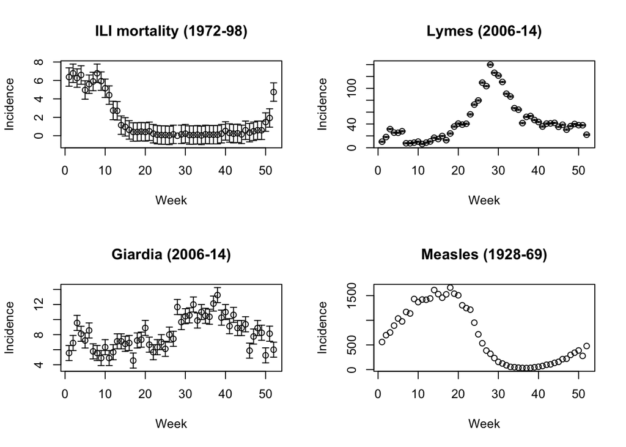

```r
par(mfrow=c(2,2)) #A four panel plot
ppp(paili[, "WEEK"], paili[,"PENNSYLVANIA"])
title("ILI mortality (1972-98)")
ppp(palymes[,"WEEK"], palymes[,"PENNSYLVANIA"])
title("Lymes (2006-14)")
ppp(pagiard[,"WEEK"], pagiard[,"PENNSYLVANIA"])
title("Giardia (2006-14)")
ppp(pameasle[,"WEEK"], pameasle[,"PENNSYLVANIA"])
title("Measles (1928-69)")
```

Seasonality arises from a variety of causes depending on the mode of transmission of the pathogen: air-borne (like influenza), vector-borne or water/food-borne. Lyme’s disease, for example, is caused by tick-vectored bacteria in the genus *Borrelia*. The figure shows the sharply seasonal incidence of human cases of Lyme’s in Pennsylvania. The seasonality is the combined effect of seasonality in tick activity levels and human use of wilderness. Most mosquito-vectored pathogens also show strong seasonality because of the temperature- and precipitation-dependence of the vector life cycle. The seasonality of cholera infections, caused by the *Vibrio cholerae* bacterium, is among the most studied water-borne pathogens. The seasonality in southeast Asia is caused by rainfall variation associated with the monsoon season. However, other water-borne diseases like giardiasis caused by protozoans in the genus *Giardia* also show marked seasonality. Host behavior can further cause seasonality in contact rates. Childhood disease dynamics, for example, are often shaped by ``term-time’’ forcing: increased transmission when schools are open. Weekly average pre-vaccination incidence of measles in Pennsylvania, for instance, collapses as school closes for the summer only to resume robust circulation after the vacation ends. Additionally, seasonal urban-rural migration in Niger, has been shown to generate strong seasonality in measles transmission.

```r
seirmod=function(t, y, parms) {
    S = y[1]
    E = y[2]
    I = y[3]
    R = y[4]

    with(as.list(parms), {
        dS = mu * (N - S) - beta * S * I/N
        dE = beta * S * I/N - (mu + sigma) * E
        dI = sigma * E - (mu + gamma) * I
        dR = gamma * I - mu * R
        res = c(dS, dE, dI, dR)
        list(res)
    })
}
```

We can simulate 10 years of dynamics using the basic recipe. The seasonally forced SEIR model has been successfully applied to understand the dynamics of measles and other immunizing childhood infections. To simulate a measles-like pathogen assume a latent period of 8 days and an infectious period of 5 days. Assume the initial host population to be $0.1\%$ infectious, $6\%$ susceptibles and the rest immune; The $R_0$ of measles is typically quoted in the 13–20 range, which means that the equilibrium fraction of susceptibles is somewhere around $5\%$. For simplicity assume a host life span of 50 years and set $N=1$ to model the fraction in each compartment.

```r
require(deSolve)
times  = seq(0, 10, by=1/120)
paras  = c(mu = 1/50, N = 1, beta =  1000,
     sigma = 365/8, gamma = 365/5)
start = c(S = 0.06, E = 0, I = 0.001, R = 0.939)
```

The $R_0$ for this system, assuming disease induced mortality is negligible, is $\frac{\sigma}{\sigma +\mu} \frac{\beta}{\gamma+\mu}$.We can verify that our choice of $\beta$ places $R_0$ in the measles-like range. We use *quote* to define the equation for $R_0$.

```r
R0=quote(sigma/(sigma+mu) * beta / (gamma+ mu))
with(as.list(paras), eval(R0))
```

```
## [1] 13.68888
```

The integrated ODEs plotted in time and in the phase plane reveales that, as is the case of the SIR model, the unforced SEIR model, predicts dampened oscillations toward the endemic equilibrium when $R_0$ is above one.

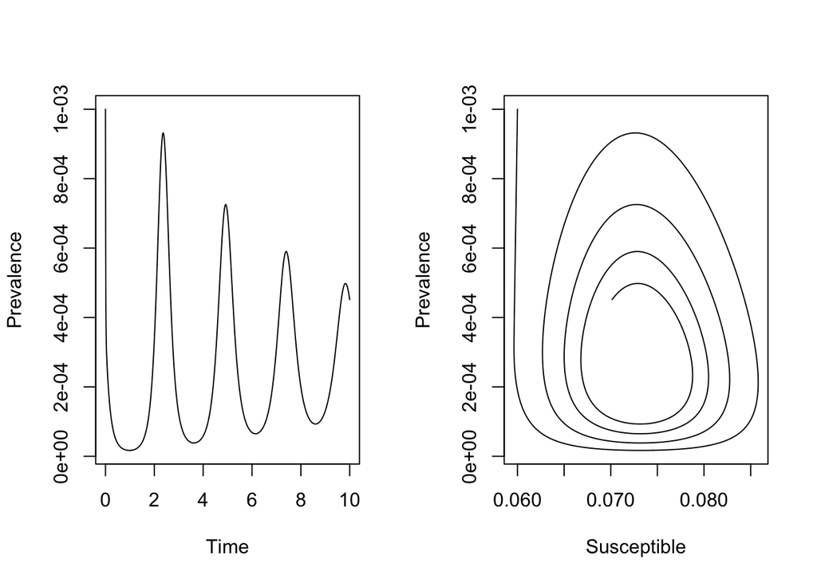

```r
out = as.data.frame(ode(start, times, seirmod, paras))
par(mfrow = c(1,2))  #Two plots side by side
plot(times, out$I, ylab = "Prevalence",
     xlab = "Time", type = "l")
plot(out$S, out$I, ylab = "Prevalence",
     xlab = "Susceptible", type = "l")
```

The Predicted prevalence from the SEIR model in time, and in the phase plane with $\mu = 1/50$, $N = 1$ (to model fractions), $\beta = 1000$, $\sigma = 365/8$ and $\gamma = 365/5$. Ten years are not long enough for the simulation to settle on the endemic equilibrium, but the dampened cycles are apparent.

```r
seirmod2=function(t, y, parameters){
  S=y[1]
  E=y[2]
  I=y[3]
  R=y[4]

 with(as.list(parameters),{
  dS = mu * (N  - S)  - beta0 * (1+beta1*cos(2*pi*t))* S * I / N
  dE = beta0 * (1+beta1*cos(2*pi * t))* S * I / N - (mu + sigma) * E
  dI = sigma * E - (mu + gamma) * I
  dR = gamma * I - mu * R
  res=c(dS, dE, dI, dR)
  list(res)
})
}
```

With no seasonality the model predicts dampened oscillation, with moderate seasonality the prediction is low-amplitude annual outbreaks. However, as seasonality increases (to $\beta_1 = 0.2$, say) we start seeing some surprising consequences of the seasonal forcing; the appearance of harmonic resonance between the internal cyclic dynamics of the SEIR clockwork and the annual seasonal forcing function.

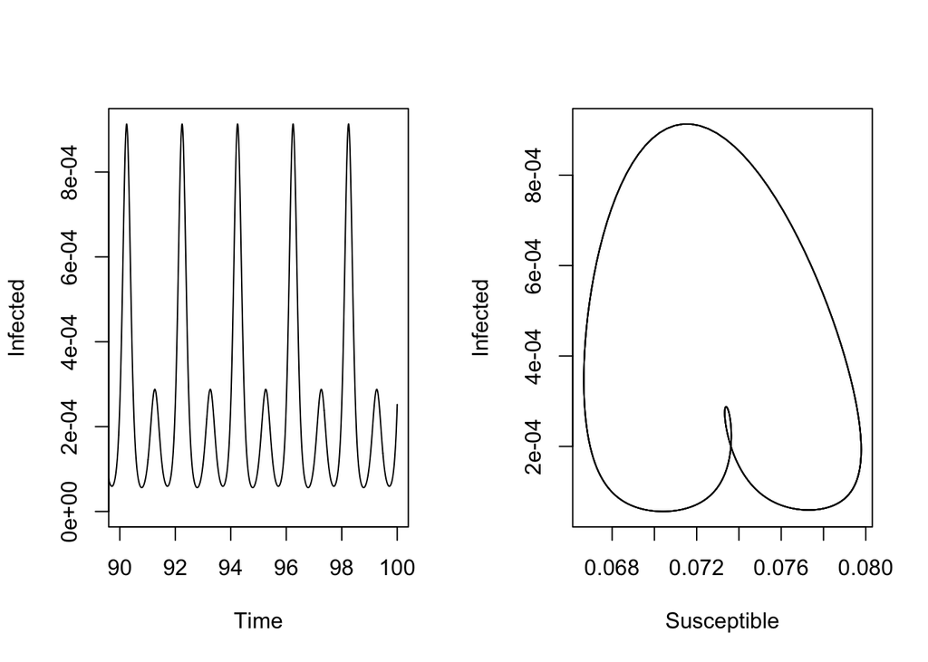

```r
times  = seq(0, 100, by=1/120)
paras  = c(mu = 1/50, N = 1, beta0 = 1000, beta1 = 0.2,
     sigma = 365/8, gamma = 365/5)
start = c(S = 0.06, E = 0, I = 0.001, R = 0.939)
out = as.data.frame(ode(start, times, seirmod2, paras))
par(mfrow = c(1, 2)) #Side-by-side plot
plot(times, out$I, ylab="Infected", xlab="Time",
     xlim = c(90, 100), ylim = c(0,
         max(out$I[11001:12000])), type = "l")
plot(out$S[11001:12000], out$I[11001:12000],
         ylab = "Infected", xlab = "Susceptible", type = "l")
```

The 10 last years of the forced SEIR model for $\beta_1=0.2$. Predicted prevalence and the S-I phase plane

The emergent pattern of recurrence in the forced SEIR is the result of an interaction between the internal periodic clockwork (the damping period) of the SEIR flow and the externally imposed periodic forcing.

The *seir.app* is a shiny for the seasonally forced model:

```r
runApp(seir.app)
```